# Situación Problema: Entrega 1

Author

Yoseba & Pedro & Santiago

### Extracción de datos

```r
data = read.csv("../data/eod_2017_csv/tviaje_eod2017/conjunto_de_datos/tviaje.csv", stringsAsFactors = TRUE)
```

```r
data2 = read.csv("../data/eod_2017_csv/ttransporte_eod2017/conjunto_de_datos/ttransporte.csv", stringsAsFactors = TRUE)
```

#### Diccionario de columnas:

```r
diccionario = read.csv("../data/eod_2017_csv/tviaje_eod2017/diccionario_de_datos/diccionario_datos_tviaje.csv", stringsAsFactors = TRUE)
```

```r
diccionario2 = read.csv("../data/eod_2017_csv/ttransporte_eod2017/diccionario_de_datos/diccionario_datos_ttransporte.csv", stringsAsFactors = TRUE)
```

**Se renombrarán las columnas de esta manera**

edad = A

sexo = S

estrato = E

p5_11a = D

p5_9_1 = T1

p5_10_2 = T2

p5_15_01 = C

p5_15_07 = B

p5_15_09 = M

p5_15_02 = Mi

p5_15_05 = Me

p5_15_06 = M1

p5_15_08 = Au

p5_15_11 = Mx

p5_15_10 = Tr

p5_15_12 = Tl

p5_15_13 = Ts

p5_3 = Day

**Significado de cada columna:**

A = Edad

S = Sexo

E = Estrato

D = ¿Qué tipo de lugar fue el destino de su viaje?

T1 = ¿A qué hora comenzó?

T2 = ¿A qué hora terminó?

C = ¿cuántas veces usó 01 Automóvil?

B = ¿cuántas veces usó 07 Bicicleta?

M = ¿cuántas veces usó 09 Moto?

Mi = ¿cuántas veces usó 02 Colectivo/Micro?

Me = ¿cuántas veces usó 05 Metro?

M1 = ¿cuántas veces usó 06 Autobús RTP o M1?

Au = ¿cuántas veces usó 08 Autobús?

Mx = ¿cuántas veces usó 11 Metrobús o Mexibús?

Tr = ¿cuántas veces usó 10 Trolebús?

Tl = ¿cuántas veces usó 12 Tren ligero?

Ts = ¿cuántas veces usó 13 Tren suburbano?

Day = Día de viaje

```r
columnas_deseadas = c("edad", "sexo", "p5_11a", "estrato", "p5_9_1", "p5_10_2",
                     "p5_15_01", "p5_15_07", "p5_15_09", "p5_15_02",
                     "p5_15_05", "p5_15_06", "p5_15_08", "p5_15_11",
                     "p5_15_10", "p5_15_12", "p5_15_13")

df_seleccionado = data[, columnas_deseadas]

names(df_seleccionado) = c("A", "S", "D", "E", "T1", "T2",
                          "C", "B", "M", "Mi", "Me", "M1",
                          "Au", "Mx", "Tr", "Tl", "Ts")
```

```r
sexo = read.csv("../data/eod_2017_csv/tviaje_eod2017/catalogos/sexo.csv", stringsAsFactors = TRUE)
head(sexo)
```

| cve | descrip |
| --- | --- |
| 1 | Hombre |
| 2 | Mujer |

Hombre corresponde a **sexo = 1**

Mujer corresponde a **sexo = 2**

### Querie 1

Para personas jóvenes de estrato bajo, ¿qué es más probable que su viaje dure más de 30 minutos o que dure menos?

Para este querie vamos a ocupar las siguientes columnas: A, E, T1, T2

```r
library(bnlearn)
```

#### Filtro del dataframe

```r
data_1 = df_seleccionado[, c("A", "E", "T1", "T2")]
```

```r
data_convertida = as.data.frame(lapply(data_1, as.factor))
```

#### Calculo de la DAG

```r
best_dag = hc(data_convertida)
```

```r
modelstring(best_dag)
```

```
[1] "[A][E|A][T1|A][T2|T1]"
```

```r
score(best_dag, data = data_convertida, type = "aic")
```

```
[1] -5520604
```

#### Grafica de la DAG

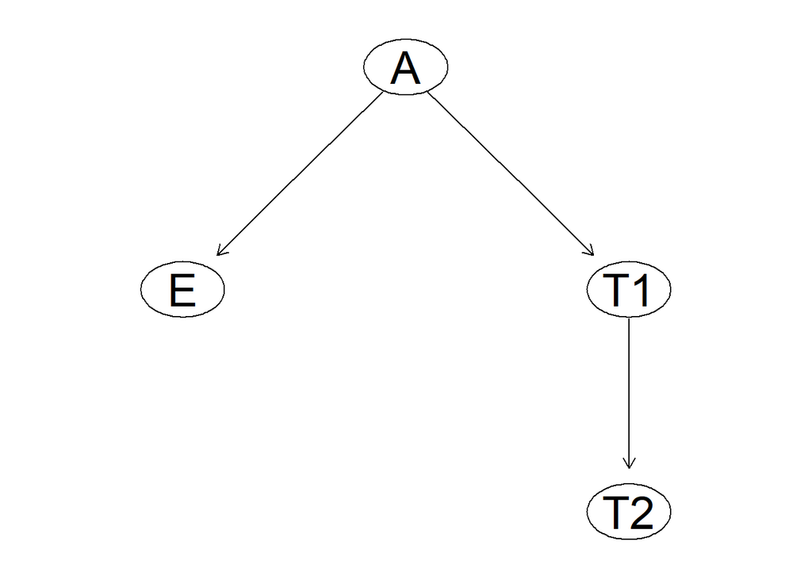

```r
graphviz.plot(best_dag, shape = "ellipse")
```

```r
bn = bn.fit(best_dag, data = data_convertida)
```

#### Querie de probabilidades

```r
prob_mas_30 <- cpquery(bn, event = (as.numeric(as.character(T2)) - as.numeric(as.character(T1)) > 30), evidence = (E == "1" & as.numeric(as.character(A)) < 18), n = 10^6)

prob_mas_30
```

```
[1] 0.156871
```

```r
prob_menos_30 <- cpquery(bn, event = (as.numeric(as.character(T2)) - as.numeric(as.character(T1)) <= 30), evidence = (E == "1" & as.numeric(as.character(A)) < 18), n = 10^6)

prob_menos_30
```

```
[1] 0.8210744
```

#### Conclusión

Lo más probable es que el viaje dure menos de 30 minutos con una probabilidad de 0.821.

### Querie 2:

¿Quién gasta más en transporte, las personas adultas que son mujeres y van a sus trabajos? ¿O las mujeres jóvenes que van a sus hogares?

```r
col_deseadas <- c("sexo", "edad", "p5_23", "p5_11a")
df_selec <- data[, col_deseadas]
names(df_selec) <- c("S", "A", "T", "D")
```

```r
df_selec$GrupoEdad <- ifelse(df_selec$A < 18, "joven", "adulto")
```

```r
df_selec$T <- suppressWarnings(as.numeric(df_selec$T))
df_selec$S <- as.factor(df_selec$S)
df_selec$D <- as.factor(df_selec$D)
df_selec$GrupoEdad <- factor(df_selec$GrupoEdad, levels = c("joven","adulto"))
```

```r
data_3 <- df_selec[, c("S", "GrupoEdad", "D", "T")]
```

```r
data_3 <- na.omit(data_3)
```

```r
data_conv = as.data.frame(lapply(data_3, as.factor))
```

```r
set.seed(123)
best_dag <- hc(data_3, score = "bic-cg")      # <- importante para mixtos
bn <- bn.fit(best_dag, data = data_3)
```

```r
modelstring(best_dag)
```

```
[1] "[S][GrupoEdad][D][T|S:D]"
```

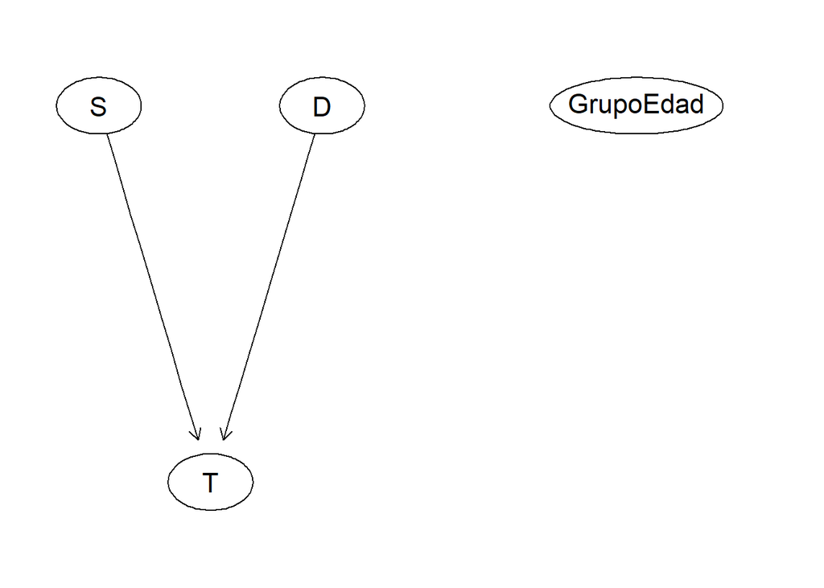

```r
graphviz.plot(best_dag, shape = "ellipse")
```

```r
library(bnlearn)
set.seed(123)
best_dag <- hc(data_3, score = "bic-cg")
bn <- bn.fit(best_dag, data = data_3)
```

```r
muestra_adultas <- cpdist(
  bn,
  nodes = "T",
  evidence = list(S = "2", GrupoEdad = "adulto", D = "3"),
  method = "lw",
  n = 1e5
)
gasto_adultas <- mean(muestra_adultas$T, na.rm = TRUE)
gasto_adultas
```

```
[1] 427.2242
```

```r
muestra_jovenes <- cpdist(
  bn,
  nodes = "T",
  evidence = list(S = "2", GrupoEdad = "joven", D = "1"),
  method = "lw",
  n = 1e5
)
gasto_jovenes <- mean(muestra_jovenes$T, na.rm = TRUE)
gasto_jovenes
```

```
[1] 1281.005
```

#### Conclusión

En promedio gastan mas las personas jovenes que van a sus hogares

### Querie 3:

¿Qué tan probable es que una persona viaje entre semana con un transporte privado dado que sea una mujer entre 60 y 80 años?

#### Filtro del dataframe

```r
columnas_deseadas2 = c("edad", "p5_3", "sexo", "p5_11a", "estrato", "p5_9_1", "p5_10_2",
                     "p5_15_01", "p5_15_07", "p5_15_09", "p5_15_02",
                     "p5_15_05", "p5_15_06", "p5_15_08", "p5_15_11",
                     "p5_15_10", "p5_15_12", "p5_15_13")

df_seleccionado2 = data[, columnas_deseadas2]

names(df_seleccionado2) = c("A", "Day", "S", "D", "E", "T1", "T2",
                          "C", "B", "M", "Mi", "Me", "M1",
                          "Au", "Mx", "Tr", "Tl", "Ts")
```

```r
data_2 = df_seleccionado2[, c("Day", "C", "S", "A")]
```

```r
data_convertid2 = as.data.frame(lapply(data_2, as.factor))
```

#### Cálculo de la DAG

```r
best_dag2 = hc(data_convertid2)
```

```r
modelstring(best_dag2)
```

```
[1] "[C][S|C][A|C:S][Day|S:A]"
```

```r
colSums(is.na(data_convertid2))
```

```
   Day      C      S      A
     0 419346      0      0
```

```r
data_cc <- na.omit(data_convertid2)

score(best_dag2, data = data_cc, type = "aic")
```

```
[1] -626935.4
```

#### Gráfica de la DAG

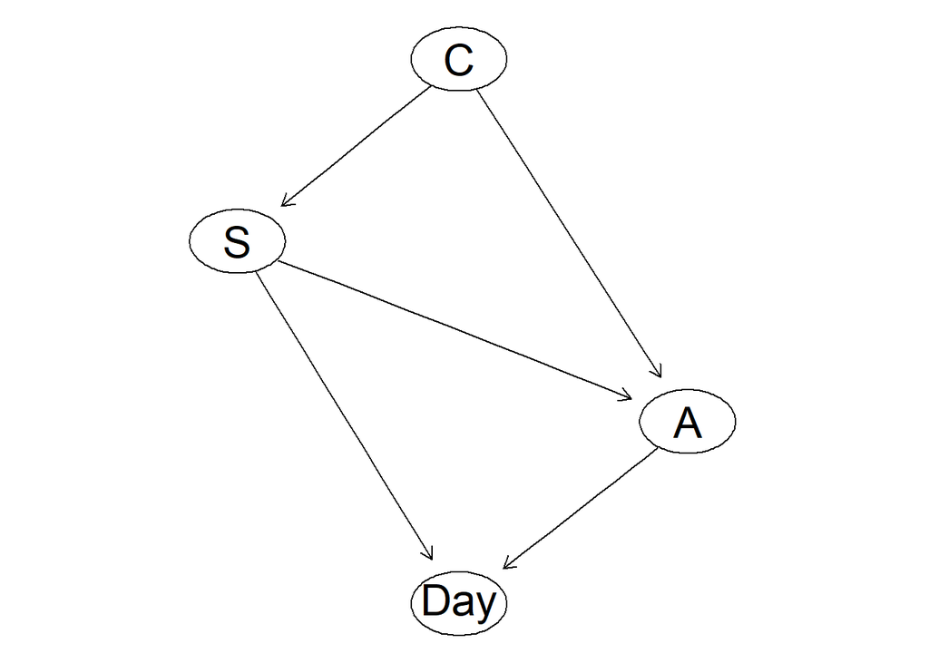

```r
graphviz.plot(best_dag2, shape = "ellipse")
```

```r
bn = bn.fit(best_dag2, data = data_convertid2)
```

#### Querie de probabilidades

```r
prob_1_S <- cpquery(bn, event = ((Day == "1") & (C == "1")), evidence = ((S == "2") & ((as.numeric(as.character(A))>= 60)&(as.numeric(as.character(A)) <= 80 ))), n = 10^6)

prob_1_S
```

```
[1] 0.5800108
```

## Querie 4:

¿Los viajes en estratos bajos tienden a ser más largos en transporte público que en automóvil?

```r
col_deseadas <- c("estrato", "p5_9_1", "p5_9_2", "p5_10_1", "p5_10_2", "p5_14_01", "p5_14_02")
df_selec <- data[, col_deseadas]
names(df_selec) <- c("E", "I", "M", "H", "F", "Auto", "TPublico")
```

```r
df_selec$Duracion <- (df_selec$H - df_selec$I) * 60 + (df_selec$F - df_selec$M)
```

```r
data_4 <- df_selec[, c("Auto", "Duracion", "TPublico", "E")]
```

```r
data_4 <- na.omit(data_4)
```

```r
data_4$Auto <- as.factor(data_4$Auto)
data_4$TPublico <- as.factor(data_4$TPublico)
data_4$E <- as.factor(data_4$E)
```

```r
set.seed(123)
best_dag <- hc(data_4, score = "bic-cg")      # <- importante para mixtos
bn <- bn.fit(best_dag, data = data_4)
```

```r
modelstring(best_dag)
```

```
[1] "[Auto][TPublico|Auto][E|Auto:TPublico][Duracion|Auto:TPublico:E]"
```

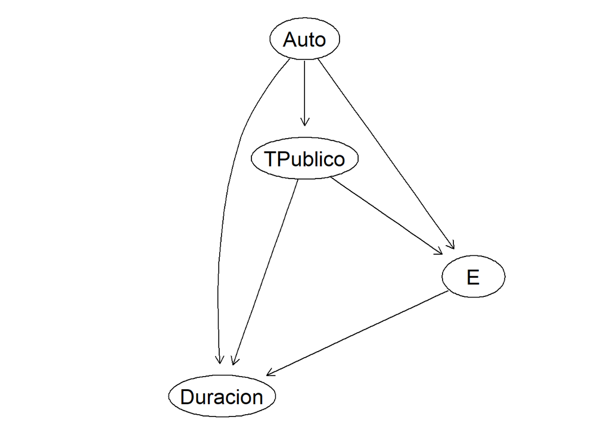

```r
graphviz.plot(best_dag, shape = "ellipse")
```

```r
estrato_bajo <- subset(df_selec, E == 1)
```

```r
auto <- subset(estrato_bajo, Auto == 1)       #
publico <- subset(estrato_bajo, TPublico == 1) #
```

```r
mean_auto <- mean(auto$Duracion, na.rm = TRUE)
mean_publico <- mean(publico$Duracion, na.rm = TRUE)
```

```r
mean_auto
```

```
[1] 55.91935
```

```r
mean_publico
```

```
[1] 81.3975
```

#### Conclusion

En promedio los viajes en transporte publico suelen ser mas largos con respecto a los viajes en auto en el estrato bajo